# Midterm Exam

DSO 424. Business Forecasting

Exam time: 10:00 am - 6:00 pm PST

# INSTRUCTIONS

The test is a take-home, open-book, and open-notes. You are not allowed to discuss and/or receive help from anyone either in class or not, either human or not :).

Download Rmd file from Blackboard to include your answers there. Your answers should be clear. Make sure to answer all questions.

You will be asked to submit Rmd file with your solution on BB.

## Alomega Food stores case

Alomega Food Stores is a retail food provider with 27 stores in a Midwestern state. The company engages in various kinds of advertising and, until recently, had never studies the effect its advertising have on sales, although some data had been collected and stored for 3 years.

The executives at Alomega decided to begin tracking their advertising effors along with the sales volumes for each month. Their hope is that after several months the collected data could be examined to possibly reveal relationships that would help in determining future advertising expenditures and forecast sales.

After a few months of collecting data and analyzing past records, the accounting department completed a data array for 48 months using the following variables:

(-) Sales in dollars

(-) Newspaper advertising dollars

(-) TV advertising dollars

Data can be found in *Alomega.csv*.

### Objective

You’ve been hired as a consultant to a team that works on this problem. You need to find a way to forecast the sales and quantify the effect advertising has on sales. You decide to start with quantifying the advertising effect on the sales. Then you consider forecasting sales based on past records only.

## How much advertising is really worth?

In the effort of identifying which factors drive sales, you decided to start with identifying whether advertising is really worth its cost. Perform your analysis using ALL data available.

1. Choose either Newspaper advertising or TV advertising as an explanatory variable. Clearly identify which type of advertising you’ve selected and briefly explain why. You will use this *type* of advertising throughout your analysis. # TV advertising # This is becasue of the impact of visual media in advertising. TV ads can influence a larger audience, potentially leading to a more significant impact on sales compared to newspaper advertising. Additionally, the visual and auditory components of TV advertising might have a stronger effect on consumer behavior.
2. Visualize your data. Produce a scatter plot of the Sales in dollars and advertising variable you’ve selected above. Decide which variable is explanatory, $X$, and which one is the dependent variable, $Y$. Clearly label the axis. Include your script. Comment on the association pattern in your plot.

```r
data=read.csv("Alomega(1).csv", header = T)
head(data, 5)
```

|  | Date | Sales | Paper | TV | logSales | logPaper | logTV |
| --- | --- | --- | --- | --- | --- | --- | --- |
| 1 | 3-Jan | 425000 | 75300 | 114000 | 12.96002 | 11.228611 | 11.64774 |
| 2 | 3-Feb | 315000 | 15000 | 63600 | 12.66130 | 9.618203 | 11.06035 |
| 3 | 3-Mar | 432000 | 134000 | 65000 | 12.97641 | 11.808873 | 11.08196 |
| 4 | 3-Apr | 357000 | 120000 | 66800 | 12.78603 | 11.693078 | 11.11009 |
| 5 | 3-May | 348000 | 136000 | 39600 | 12.75960 | 11.817391 | 10.58724 |

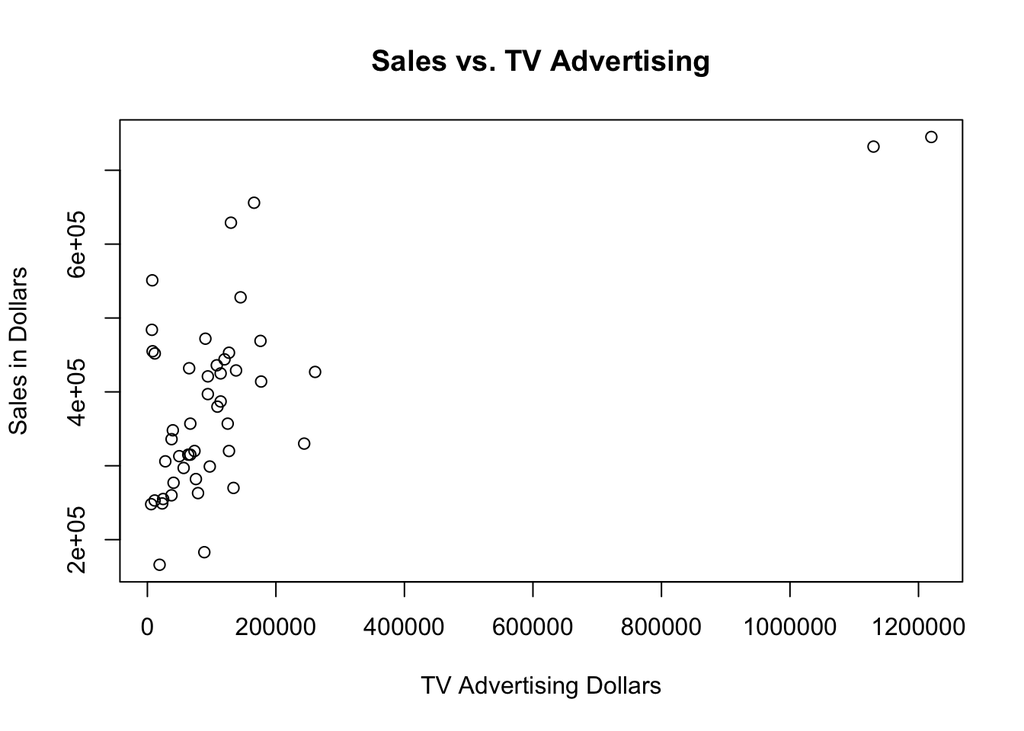

```r
attach(data)
plot(TV, Sales, main="Sales vs. TV Advertising", xlab="TV Advertising Dollars", ylab="Sales in Dollars")
```

# Sales in dollars (dependent variable, Y) against TV advertising dollars (explanatory variable, X) # From the plot, we can observe a pattern that suggests a positive association between the amount spent on TV advertising and sales; as the expenditure on TV advertising increases, sales also tend to increase. This initial observation supports the notion that TV advertising could have a positive impact on sales, although the relationship does not appear to be perfectly linear, and there is some variability in sales even at similar levels of TV advertising spending.

You’ve decided to focus on the log-log model since you suspect that percentage increase in advertising leads to constant percentage changes in the sales. This approach would allow you compare effects of different types of advertising if needed. Use the records in the last three columns in the *Alomega.csv* file that have the log-transformed data available (natural log).

3. Use the log-transformed data to fit the linear regression model that predicts percent changes in sales, i.e. logSales. Write down your model. Produce a scatterplot with the fitted regression line in red. Label axis nicely. Include your script.

```r
lm_model = lm(logSales ~ logTV, data=data)
lm_model
```

```
##
## Call:
## lm(formula = logSales ~ logTV, data = data)
##
## Coefficients:
## (Intercept)        logTV
##     11.4502       0.1223
```

```r
summary(lm_model)
```

```
##
## Call:
## lm(formula = logSales ~ logTV, data = data)
##
## Residuals:
##      Min       1Q   Median       3Q      Max
## -0.72695 -0.19939 -0.01383  0.13375  0.67749
##
## Coefficients:
##             Estimate Std. Error t value Pr(>|t|)
## (Intercept) 11.45016    0.42816  26.743  < 2e-16 ***
## logTV        0.12227    0.03825   3.196  0.00255 **
## ---
## Signif. codes:  0 '***' 0.001 '**' 0.01 '*' 0.05 '.' 0.1 ' ' 1
##
## Residual standard error: 0.2964 on 45 degrees of freedom
## Multiple R-squared:  0.185,  Adjusted R-squared:  0.1669
## F-statistic: 10.22 on 1 and 45 DF,  p-value: 0.002545
```

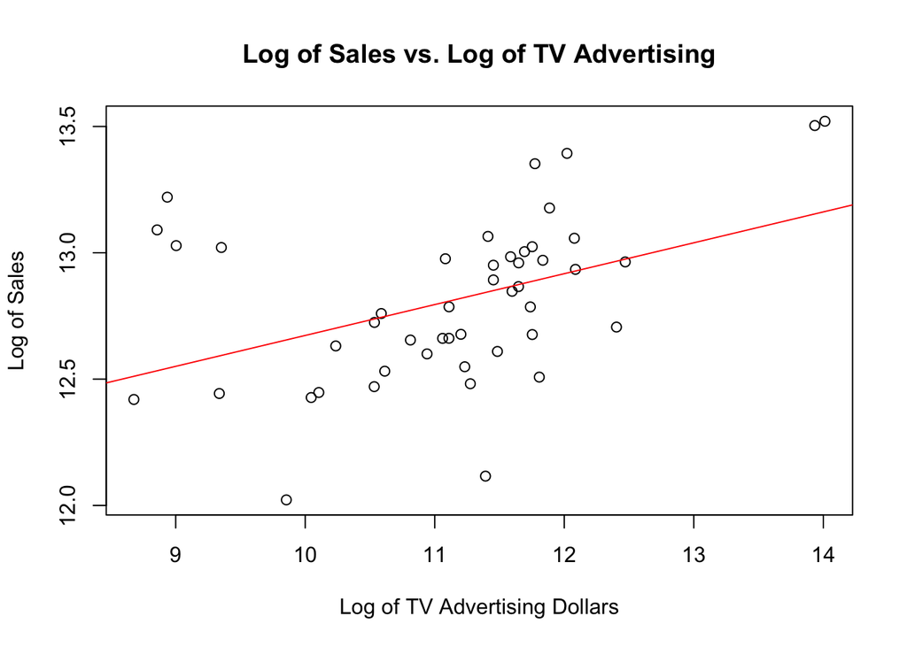

```r
plot(logTV, logSales, main="Log of Sales vs. Log of TV Advertising", xlab="Log of TV Advertising Dollars", ylab="Log of Sales")
abline(lm_model, col="red")
```

# The linear regression model fitted on the log-transformed data is given by: logSales = 11.4502 + 0.1223 × logTV –> where a 1% increase in TV advertising dollars (after log transformation) is associated with an average increase of 0.1223% in sales, holding all other factors constant.

4. Does advertising REALLY effect sales? Run a hypothesis test. Report the p-value and your conclusion. Include your script.

```r
summary(lm_model)
```

```
##
## Call:
## lm(formula = logSales ~ logTV, data = data)
##
## Residuals:
##      Min       1Q   Median       3Q      Max
## -0.72695 -0.19939 -0.01383  0.13375  0.67749
##
## Coefficients:
##             Estimate Std. Error t value Pr(>|t|)
## (Intercept) 11.45016    0.42816  26.743  < 2e-16 ***
## logTV        0.12227    0.03825   3.196  0.00255 **
## ---
## Signif. codes:  0 '***' 0.001 '**' 0.01 '*' 0.05 '.' 0.1 ' ' 1
##
## Residual standard error: 0.2964 on 45 degrees of freedom
## Multiple R-squared:  0.185,  Adjusted R-squared:  0.1669
## F-statistic: 10.22 on 1 and 45 DF,  p-value: 0.002545
```

# The p-value from our hypothesis test is approximately 0.0025, which is significantly less than the commonly used significance level of 0.05. This result leads us to reject the null hypothesis, indicating that TV advertising does indeed have a statistically significant effect on sales. This conclusion supports the initial observation from our scatter plot and the positive coefficient in our log-log model.

5. What percent of variability in sale changes does your model explain? Comment on practical usefulness of the model.

```r
s=summary(lm_model)
s$r.squared
```

```
## [1] 0.1850416
```

# The R-squared value for our model is approximately 0.185, indicating that around 18.5% of the variability in sales changes is explained by our model. This suggests that while TV advertising has a statistically significant impact on sales, the model explains a moderate to low portion of the variability in sales changes. It implies that other factors, not included in this model, also play significant roles in influencing sales.

6. Test the regression model assumptions. Are all assumptions met (Yes / No / More-or-less)? If not, propose a way of fixing the assumptions (you don’t have to perform additional analysis based on your suggestions).

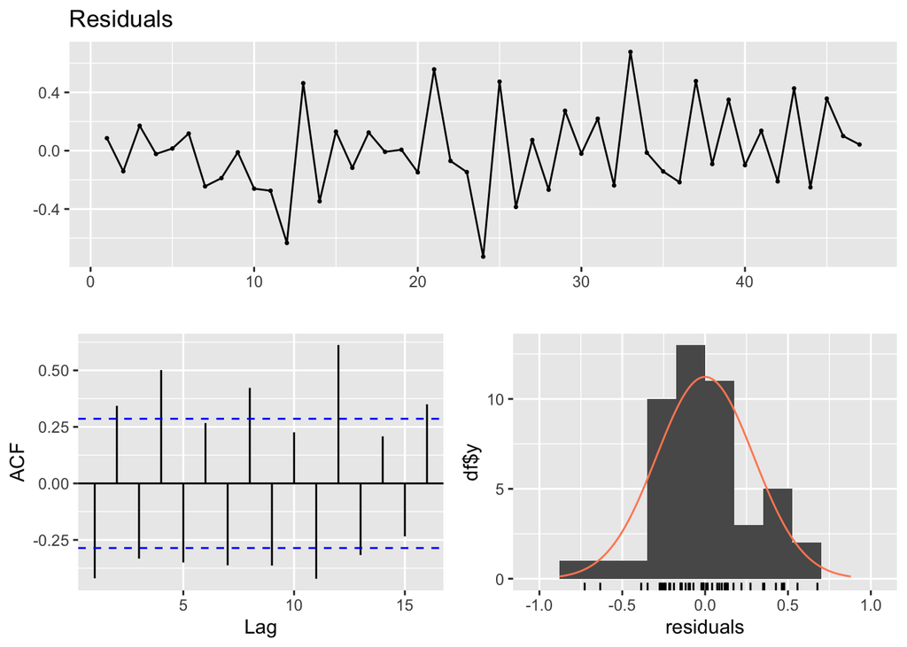

```
##
##  Breusch-Godfrey test for serial correlation of order up to 9
##
## data:  Residuals
## LM test = 18.45, df = 9, p-value = 0.0303
```

```r
library(forecast)
checkresiduals(lm_model)
```

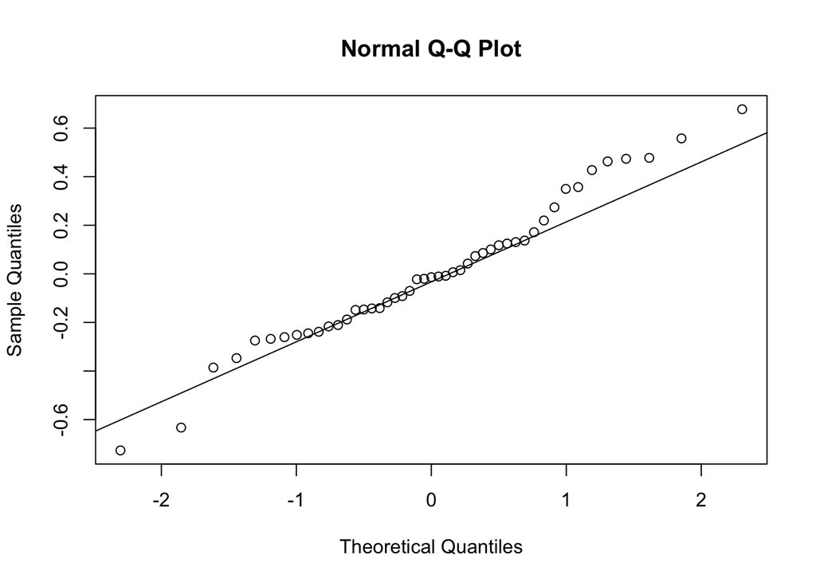

```r
# Checking for normality of residuals
qqnorm(lm_model$residuals)
qqline(lm_model$residuals)
```

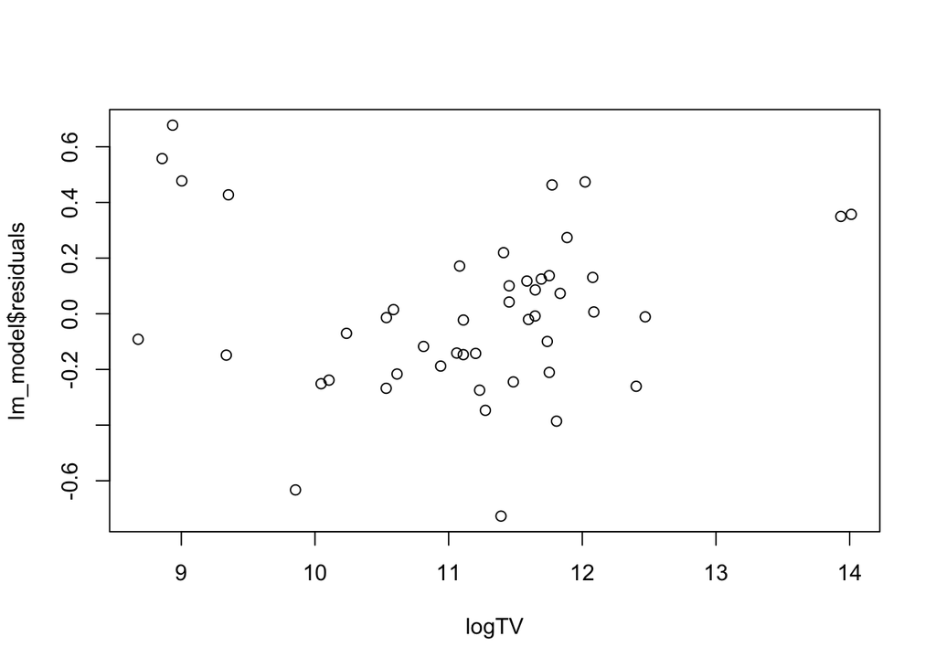

```r
# Checking for constant variance (homoscedasticity)
plot(logTV, lm_model$residuals)
```

```r
# Checking for independence
library(zoo)
library(lmtest)
dwtest(logSales~logTV, data=data, alternative = "two.sided")
```

```
##
##  Durbin-Watson test
##
## data:  logSales ~ logTV
## DW = 2.8372, p-value = 0.002778
## alternative hypothesis: true autocorrelation is not 0
```

# The Normal Q-Q Plot shows that the residuals deviate from the line at the tails, indicating that the residuals are not perfectly normally distributed, especially at the extremes.

# The spread of residuals seems to vary across the range of fitted values, suggesting potential issues with homoscedasticity, although not pronounced.

# We reject the null hypothesis for the dwtest. They are not independent.